# AE 24: North Carolina Voting

07.14.2021

## Announcements

- Exam 02 grades will be released today
- Order and time slots of project presentations will be sent out today via a Sakai announcement
- No formal lab on Friday. Treat it as drop-in office hours for help on the project

## Exercises

Today’s data set comes from the [US Elections Project](https://electproject.github.io/Early-Vote-2020G/NC.html). We will focus specifically on early voting data for North Carolina through November 1, 2020.

The variables are

- `name`: county name
- `regstrd`: number of registered voters
- `voted`: number of individuals who have voted
- `mailed`: number of mail ballots returned and accepted
- `rejectd`: number of mail ballots rejected
- `ml_rqst`: number of mail ballots requested

We first read in the file `nc_votes_nov1.shp` with the `st_read` function, saving as `nc_votes`.

```r
nc_votes <- st_read("data/nc_votes_nov1.shp", quiet = TRUE)
```

### Exercise 2

Let’s use `nc_votes` to create a map of North Carolina.

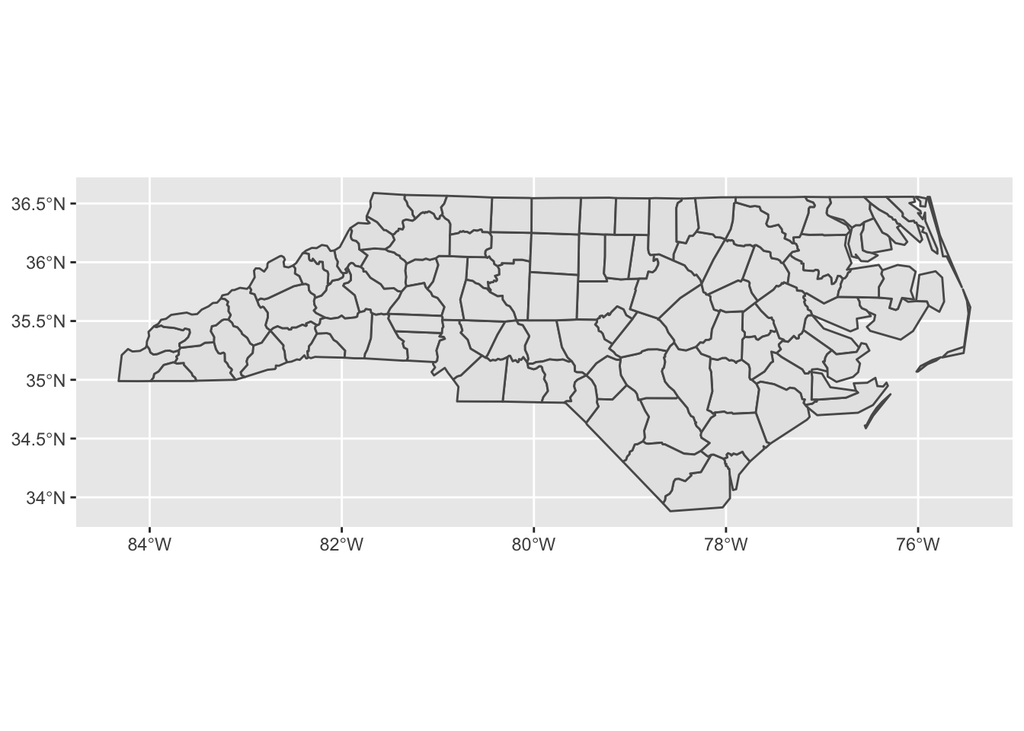

```r
ggplot(nc_votes) +
  geom_sf()
```

Starting with the code above, update the visualization so that the counties have a fill color corresponding to the percentage of requested mail-in ballots that have been returned and accepted. Include informative labels, colors and any other aesthetics.

### Exercise 3

Create a map of North Carolina where the counties have a fill color corresponding to the percentage of votes that were cast by mail. Include informative labels, colors and any other aesthetics.

### Exercise 4

Create an effective spatial data visualization using these data exploring a topic of your choosing.

Read more about factors to consider when creating election maps: https://www.nytimes.com/interactive/2020/10/30/opinion/election-results-maps.html